# Assignment 2: Electricity Market Prices

Ecemnaz Bay

2020-08-15

## Electricity Market Prices Report Brief

In this report July 2020’s electricity prices MCP/SMP data are analyzed using using dplyr and ggplot2. July 2020 data downloaded from [EPIAS/EXIST MCP/SMP Page](https://rapor.epias.com.tr/rapor/xhtml/ptfSmfListeleme.xhtml).

### Used Packages

```r
library(dplyr)
library(ggplot2)
library(lubridate)
library(tidyr)
```

### Data Exploration

#### Data Read

```r
MCPSMP  <- read.csv("C:/Users/ecemnaz.bay/Desktop/Ecemnaz/Master/IE 48A/July2020_ElectricityMarketPrices.csv")
```

##### Getting a glimpse of the data.

```r
MCPSMP %>% glimpse()
```

```
## Rows: 744
## Columns: 6
## $ Tarih                               <fct> 01.07.20 00:00, 01.07.20 01:00,...
## $ PTF                                 <dbl> 323.85, 326.95, 324.31, 322.11,...
## $ SMF                                 <dbl> 211.00, 201.00, 211.00, 211.00,...
## $ Pozitif.Dengesizlik.Fiyatý..TL.MWh. <dbl> 204.67, 194.97, 204.67, 204.67,...
## $ Negatif.Dengesizlik.Fiyatý..TL.MWh. <dbl> 333.57, 336.76, 334.04, 331.77,...
## $ SMF.Yön                             <fct> ?Enerji Fazlasý, ?Enerji Fazlas...
```

```r
MCPSMP %>%
  select(Tarih , PTF, SMF) %>%
  glimpse()
```

```
## Rows: 744
## Columns: 3
## $ Tarih <fct> 01.07.20 00:00, 01.07.20 01:00, 01.07.20 02:00, 01.07.20 03:0...
## $ PTF   <dbl> 323.85, 326.95, 324.31, 322.11, 320.00, 286.21, 210.13, 318.2...
## $ SMF   <dbl> 211.00, 201.00, 211.00, 211.00, 201.00, 181.00, 113.75, 201.0...
```

After looking to the content, some rearrangement are made on the data.

- Columns are renamed
- Date - Time information is converted to POSIXct format
- New columns are added
  - SMPMCPdiff
  - Date
  - DayofWeek
  - Hour

A new data frame is created with those modifications, called `MCPSMPRearranged`.

```r
MCPSMPRearranged <-
MCPSMP %>%
  rename(Date_Time = Tarih , MCP = PTF, SMP = SMF) %>%
  mutate(Date_Time,DateTime=as.POSIXct(factor(Date_Time), format="%d.%m.%y %H:%M"))  %>%
  mutate(SMPMCPdiff = SMP-MCP)  %>%
  transmute(DateTime,MCP,SMP, Date = as_date(DateTime), DayofWeek = wday(DateTime,label = TRUE,week_start=1) ,Hour = hour(DateTime),SMPMCPdiff)

MCPSMPRearranged %>% glimpse()
```

```
## Rows: 744
## Columns: 7
## $ DateTime   <dttm> 2020-07-01 00:00:00, 2020-07-01 01:00:00, 2020-07-01 02...
## $ MCP        <dbl> 323.85, 326.95, 324.31, 322.11, 320.00, 286.21, 210.13, ...
## $ SMP        <dbl> 211.00, 201.00, 211.00, 211.00, 201.00, 181.00, 113.75, ...
## $ Date       <date> 2020-07-01, 2020-07-01, 2020-07-01, 2020-07-01, 2020-07...
## $ DayofWeek  <ord> Wed, Wed, Wed, Wed, Wed, Wed, Wed, Wed, Wed, Wed, Wed, W...
## $ Hour       <int> 0, 1, 2, 3, 4, 5, 6, 7, 8, 9, 10, 11, 12, 13, 14, 15, 16...
## $ SMPMCPdiff <dbl> -112.85, -125.95, -113.31, -111.11, -119.00, -105.21, -9...
```

To analyze the prices over day of week :

- Average MCP and SMP values for each day of week are calculated.
- SMP-MCP difference over average MCP for each day of week are calculated.

```r
DailyAverages <-
MCPSMPRearranged %>%
  group_by(DayofWeek) %>%
  summarise(DailyAvgMCP = mean(MCP),DailyAvgSMP = mean(SMP),DailyAvgDeviationFromMCP = mean(SMPMCPdiff)/ mean(MCP))

knitr::kable(DailyAverages, format="markdown")
```

| DayofWeek | DailyAvgMCP | DailyAvgSMP | DailyAvgDeviationFromMCP |
| --- | --- | --- | --- |
| Mon | 302.0398 | 316.7281 | 0.0486305 |
| Tue | 298.8338 | 314.4270 | 0.0521803 |
| Wed | 306.9160 | 275.7717 | -0.1014751 |
| Thu | 297.0389 | 300.8255 | 0.0127478 |
| Fri | 299.2423 | 294.4326 | -0.0160728 |
| Sat | 291.8207 | 310.8506 | 0.0652109 |
| Sun | 275.0998 | 289.1030 | 0.0509024 |

To analyze the prices over hour of day :

- Average MCP and SMP values for each hour.
- SMP-MCP difference over average MCP for each hour are calculated.

```r
HourlyAverages <-
MCPSMPRearranged %>%
  group_by(Hour) %>%
  summarise(HourlyAvgMCP = mean(MCP),HourlyAvgSMP = mean(SMP),HourlyAvgDeviationFromMCP = mean(SMPMCPdiff)/ mean(MCP))

knitr::kable(HourlyAverages, format="markdown")
```

| Hour | HourlyAvgMCP | HourlyAvgSMP | HourlyAvgDeviationFromMCP |
| --- | --- | --- | --- |
| 0 | 297.3552 | 294.3274 | -0.0101822 |
| 1 | 305.8410 | 307.5423 | 0.0055627 |
| 2 | 298.1139 | 297.3471 | -0.0025721 |
| 3 | 284.3048 | 282.9535 | -0.0047530 |
| 4 | 284.8490 | 280.0355 | -0.0168986 |
| 5 | 246.7165 | 248.3558 | 0.0066447 |
| 6 | 213.3771 | 213.1577 | -0.0010280 |
| 7 | 268.8835 | 259.9181 | -0.0333434 |
| 8 | 294.5987 | 277.5932 | -0.0577242 |
| 9 | 288.2713 | 290.9119 | 0.0091603 |
| 10 | 300.7368 | 290.9277 | -0.0326167 |
| 11 | 305.1348 | 307.3297 | 0.0071930 |
| 12 | 297.5416 | 298.2952 | 0.0025326 |
| 13 | 304.1765 | 308.3671 | 0.0137770 |
| 14 | 311.8487 | 328.8610 | 0.0545529 |
| 15 | 312.6694 | 329.8229 | 0.0548616 |
| 16 | 312.4710 | 330.9177 | 0.0590352 |
| 17 | 310.6632 | 328.4894 | 0.0573809 |
| 18 | 308.5587 | 325.7868 | 0.0558340 |
| 19 | 310.3419 | 324.4110 | 0.0453340 |
| 20 | 316.6100 | 312.6990 | -0.0123526 |
| 21 | 316.9803 | 326.6026 | 0.0303560 |
| 22 | 314.4574 | 316.3365 | 0.0059755 |
| 23 | 308.1403 | 303.2048 | -0.0160170 |

### Data Visualization

Scatter plot shows that for most of the days MCP lies between 300-325 and SMP lies between 150-400.

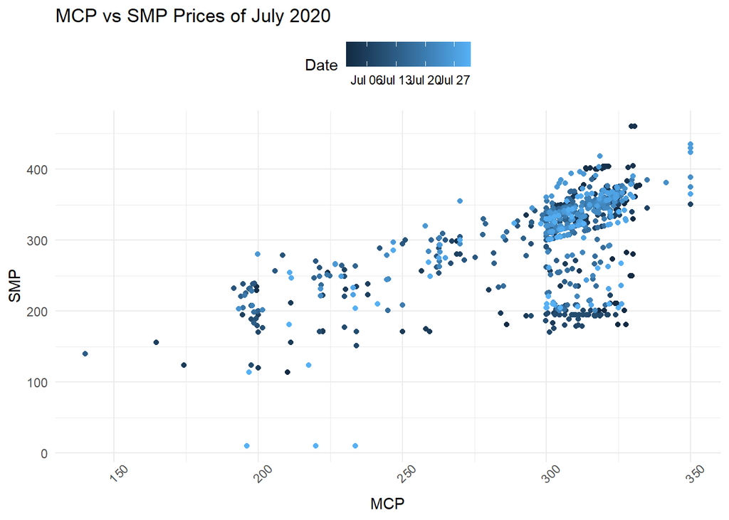

```r
ggplot(MCPSMPRearranged, aes(x=MCP, y=SMP, color=Date)) +
            geom_point() +
            theme_minimal() +
            ggtitle("MCP vs SMP Prices of July 2020") +
            labs(x = "MCP",
                 y = "SMP") +
            theme(axis.text.x = element_text(angle = 45), legend.position = "top")
```

Below bar chart shows that for Wednesday and Friday, average SMP is lower than average MCP.  
It can be concluded that, for those days energy consumption forecasts are higher than the actual consumption.  
Forecasted and actual consumption values are closer to each other on Thursdays.  
For the rest of the week, consumption is higher than the expected.

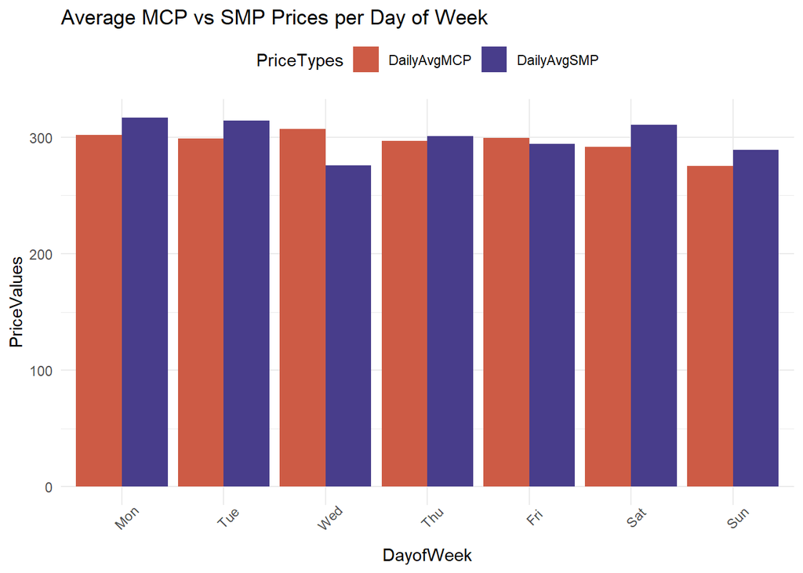

```r
DailyAveragePrices_Longer <-
DailyAverages %>%
  ungroup() %>%
  pivot_longer(cols=c(DailyAvgMCP, DailyAvgSMP), names_to="PriceTypes", values_to="PriceValues") %>%
  select(DayofWeek,PriceTypes,PriceValues)

ggplot(DailyAveragePrices_Longer, aes(x=DayofWeek, y=PriceValues, fill=PriceTypes)) +
            scale_fill_manual(values=c("coral3", "darkslateblue")) +
            theme_minimal() +
            geom_bar(stat="identity", position="dodge") +
            ggtitle("Average MCP vs SMP Prices per Day of Week") +
            theme(axis.text.x = element_text(angle = 45), legend.position = "top")
```

Same analysis can be done towards hours of the day.  
It can be seen that better forecasts are made from beginning of the day up to noon time.  
After noon up to night, average SMP is higher than MCP.  
At the second half of the day, the consumption seems higher than forecasted amount on average.

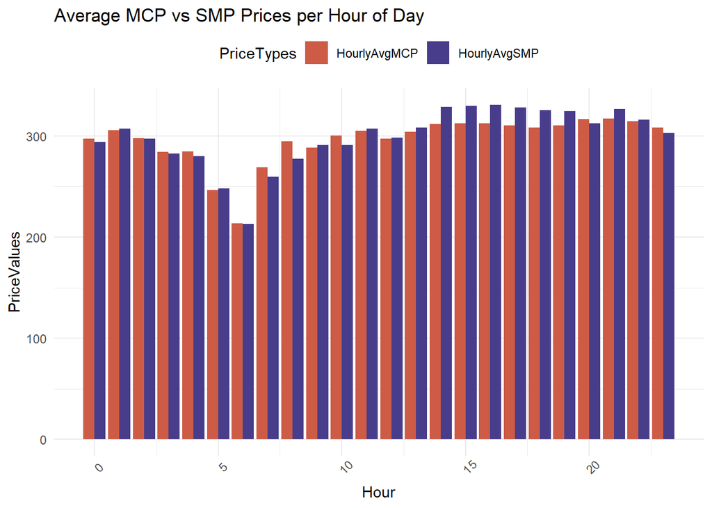

```r
HourlyAveragePrices_Longer <-
HourlyAverages %>%
  ungroup() %>%
  pivot_longer(cols=c(HourlyAvgMCP, HourlyAvgSMP), names_to="PriceTypes", values_to="PriceValues") %>%
  select(Hour,PriceTypes,PriceValues)

ggplot(HourlyAveragePrices_Longer, aes(x=Hour, y=PriceValues, fill=PriceTypes)) +
            scale_fill_manual(values=c("coral3", "darkslateblue")) +
            theme_minimal() +
            geom_bar(stat="identity", position="dodge") +
            ggtitle("Average MCP vs SMP Prices per Hour of Day") +
            theme(axis.text.x = element_text(angle = 45), legend.position = "top")
```

Trendline shows that SMP is higher than MCP for most of the days.  
There are certain spikes where the gap is higher, like beginning and ending of the month.  
Forecast accuracy improvement studies can be considered for those days.

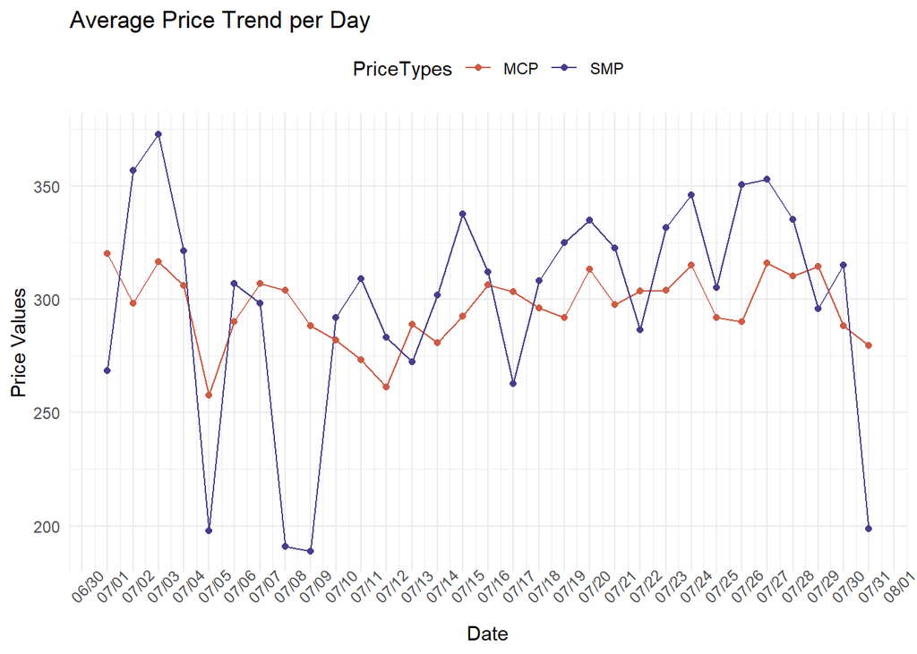

```r
MCPSMPRearranged_Longer <-
MCPSMPRearranged %>%
  group_by(Date) %>%
  summarise(MCP = mean(MCP), SMP = mean(SMP)) %>%
  ungroup() %>%
  pivot_longer(cols=c(MCP, SMP), names_to="PriceTypes", values_to="PriceValues")

ggplot(MCPSMPRearranged_Longer, aes(x=Date, y=PriceValues, color=PriceTypes)) +
           ggtitle("Average Price Trend per Day") +
           geom_line() +
           geom_point()+
           theme_minimal() +
           scale_color_manual(values=c("coral3", "darkslateblue")) +
           labs(x = "Date",
                y = "Price Values") +
           scale_x_date(date_breaks = "1 day", date_labels = "%m/%d") +
           theme(axis.text.x = element_text(angle = 45), legend.position = "top")
```

The first heat map shows that MCP is higher after morning hours.  
Specific date-time observations can be spotted with higher MCP values than normal, with darker blue color.

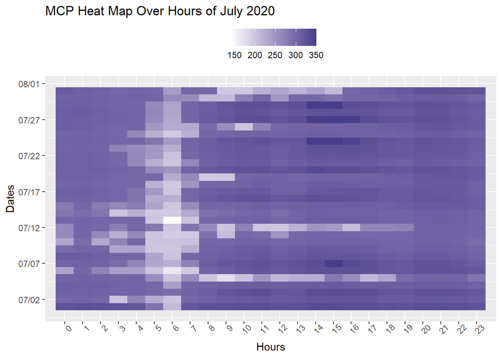

```r
ggplot(MCPSMPRearranged, aes(x=Hour, y=Date, fill=MCP)) +
  ggtitle("MCP Heat Map Over Hours of July 2020") +
  geom_tile() +
  scale_fill_gradient(low="white", high="darkslateblue") +
  labs(x = "Hours",
       y = "Dates") +
  scale_y_date(date_breaks = "5 day", date_labels = "%m/%d") +
  scale_x_discrete(limits=c(0:23)) +
  theme(axis.text.x = element_text(angle = 45), legend.position = "top",
        legend.title = element_blank())
```

The second heat map shows a summary of average MCP values for different hours of each day of week.  
For Friday, MCP is lower than other days between 9 am and 3 pm on average.  
The highest average MCP is observed on Monday from 2pm to 4pm and on Wednesday from 2pm to 3pm.

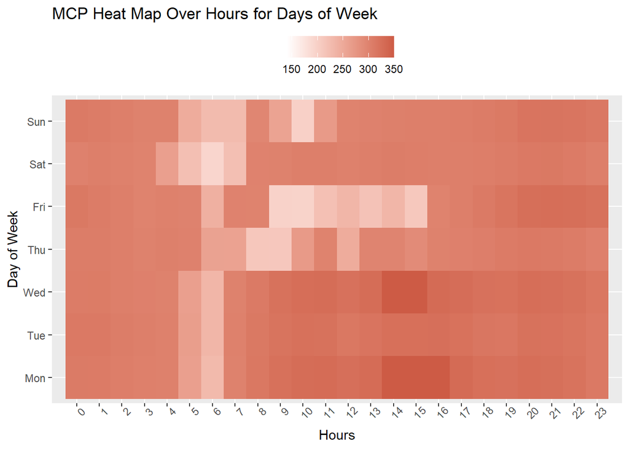

```r
ggplot(MCPSMPRearranged, aes(x=Hour, y=DayofWeek, fill=MCP)) +
  ggtitle("MCP Heat Map Over Hours for Days of Week") +
  geom_tile() +
  scale_fill_gradient(low="white", high="coral3") +
  labs(x = "Hours",
       y = "Day of Week") +
  scale_x_discrete(limits=c(0:23)) +
  theme(axis.text.x = element_text(angle = 45), legend.position = "top",
        legend.title = element_blank())
```

In the last heat map, the difference between SMP and MCP is summarized for each day of week.  
Lighter fill colors indicates lower SMP minus MCP values for that day of week - hour pair.  
The lowest value is seen for Friday morning hours, between 10am and 12pm which can indicate the highest energy surplus in the market.

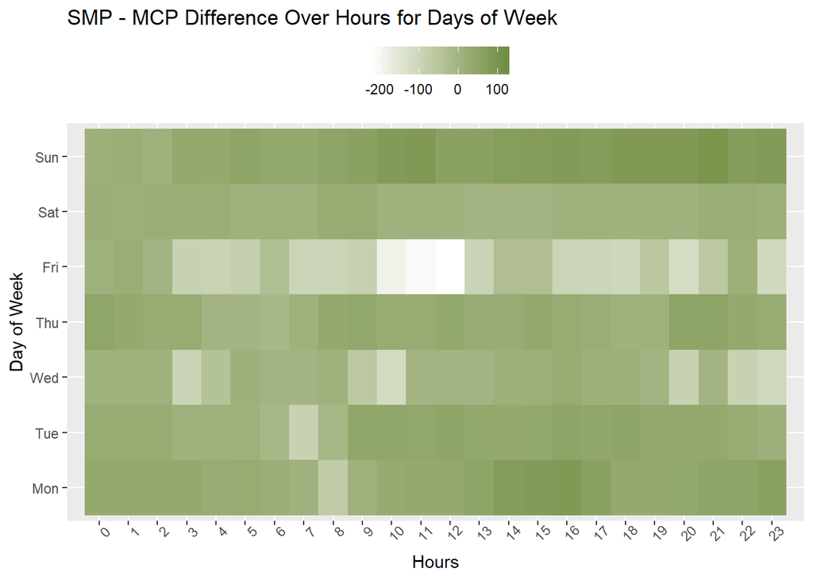

```r
ggplot(MCPSMPRearranged, aes(x=Hour, y=DayofWeek, fill=SMPMCPdiff)) +
  ggtitle("SMP - MCP Difference Over Hours for Days of Week") +
  geom_tile() +
  scale_fill_gradient(low="white", high="darkolivegreen4") +
  labs(x = "Hours",
       y = "Day of Week") +
  scale_x_discrete(limits=c(0:23)) +
  theme(axis.text.x = element_text(angle = 45), legend.position = "top",
        legend.title = element_blank())
```